# August 2015 DataJam

Tim Abram

Sunday, August 09, 2015

*Description*: R script for generating an adjacency matrix of user interests (topics) from raw Meetup data for the Houston Data Visualization group (8/8/15). *Contributors*: Tim, Gerardo, and Yuanbo

Read data from csv and get basic info

```r
dataset <-read.csv("meetupdata-Aug-08-2015.csv", header=T, as.is=T)
str(dataset)
```

```
## 'data.frame':    595 obs. of  10 variables:
##  $ X      : int  0 1 2 3 4 5 6 7 8 9 ...
##  $ status : chr  "active" "active" "active" "active" ...
##  $ city   : chr  "Houston" "Boston" "Houston" "Houston" ...
##  $ state  : chr  "TX" "MA" "TX" "TX" ...
##  $ country: chr  "us" "us" "us" "us" ...
##  $ lat    : num  29.7 42.4 29.9 29.9 29.5 ...
##  $ lon    : num  -95.2 -71.1 -95.6 -95.5 -95.2 ...
##  $ visited: chr  "12/15/14" "03/16/15" "06/29/15" "08/06/15" ...
##  $ joined : chr  "04/10/14" "03/16/15" "06/29/15" "06/20/15" ...
##  $ topics : chr  "Fitness, Buddhist, Meditation, Dining Out, Spirituality, Museum, Computer programming, Programming Languages, Functional Progra"| __truncated__ "Yorkshire Terrier, Scala, Functional Programming, Hiking, Hong Kong Culture, Entrepreneurship, Computer programming, New Techno"| __tr…
```

```r
head(dataset)
```

```
##   X status        city state country   lat    lon  visited   joined
## 1 0 active     Houston    TX      us 29.72 -95.22 12/15/14 04/10/14
## 2 1 active      Boston    MA      us 42.35 -71.07 03/16/15 03/16/15
## 3 2 active     Houston    TX      us 29.93 -95.61 06/29/15 06/29/15
## 4 3 active     Houston    TX      us 29.88 -95.45 08/06/15 06/20/15
## 5 4 active Friendswood    TX      us 29.52 -95.20 05/06/15 05/06/15
## 6 5 active     Houston    TX      us 29.93 -95.61 08/05/15 08/05/15
##                                                                                                                                                                                                                                                                                                          …
## 1 Fitness, Buddhist, Meditation, Dining Out, Spirituality, Museum, Computer programming, Programming Languages, Functional Programming, Big Data, Web Development, English as a Second Language, English Language, Young Professional Singles, Data Mining, Data Analytics, Data Visualization, New Techn…
## 2                                                                                                                                                                                                                                                                                                        …
## 3                                                                                                                                                                                                                                                                                                        …
## 4                                                                                                                                                                                                    Art, Open Mic, Performing Arts, Professional Development, Small Business Technology, Young Professio…
## 5                                                                                                                                                                                                                                                                                                        …
## 6                                                                                                                                                                                                                                                                                                        …
```

```r
library(stringr)
topics <-str_trim(toupper(unlist(strsplit(as.character(dataset[,"topics"]), ","))))
```

There are 1899 unique topics in the given dataset.

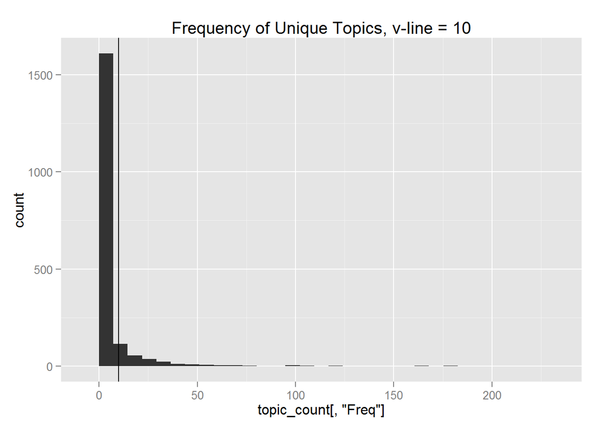

```r
topic_count <-as.data.frame(table(topics))
topic_count <-topic_count[(order(topic_count$Freq)),]

library(ggplot2)
ggplot(topic_count, aes(x=topic_count[,"Freq"])) +geom_histogram()+geom_vline(x=10)+
  ggtitle('Frequency of Unique Topics, v-line = 10')
```

Next, we needed to relate the separate topics back to their unique users by creating a sparse matrix of columns for each topic where 1 = user-topic match and 0 = no match. (This code was created by Yuanbo; check out his [R file on the github page](https://github.com/houstondatavis/data-jam-august-2015/blob/master/Table_R_Code.R))

```r
  all_tp<-topics
  unique_tp<-unique(topics)
  tp <-dataset$topics

 tp_list<-list()
    for(i in 1:length(tp)){
        tp_list[[i]]<-unlist(strsplit(tp[i],","))
    }
#====CREATE COLUMNS DATA FRAME=======
    col<-matrix(data=0,nrow=length(tp_list),ncol=length(unique_tp))
    for (j in 1:length(tp_list)){
        idx<-which(tp_list[[j]] %in% unique_tp)
        col[j,idx]<-1
    }
    colDF<-data.frame(col)
    names(colDF)<-unique_tp
#====OUTPUT PROCESSED FILES=======
    #dt_output<-cbind(dt,colDF)
    #write.csv(dt.output,"meetupdata-Aug-08-2015-mod.csv",row.names=F,col.names=T)
```

Gerardo used an alternative method for linking users to their individual topics by expanding the original table so that each row contained a single topic (repeated user info/user IDs for users with more than 1 topic in their original topic “list”). With this table, he could use the `cast` function in `library(reshape2)` to create a new table of unique topics (columns) by the unique userIDs (rows).

Of the 595 users in the raw dataset, 80 users didn’t list any topics; the matrix returned upon the merge function contained the remaining 515 users. By increasing the cutoff frequency for topics (the inclusion criteria for the final table), the total number of users would decrease if a user’s topics fell below the cutoff.

```r
library(data.table)
library(reshape2)
dataset.dt <- fread("meetupdata-Aug-08-2015.csv", head=T)

dt <- dataset.dt[, list("topics2" = unlist(strsplit(topics, ","))),
          by = list(V1)]

dt$topics2 <- toupper(str_trim(dt$topics2))

all <- merge(dataset.dt, dt, by = c("V1"))
all <- all[,!"topics", with=FALSE]
all$value <- 1

head(topic_count)
```

```
##                       topics Freq
## 1                   & CUMBIA    1
## 3            .NET DEVELOPERS    1
## 5  1031 REAL ESTATE EXCHANGE    1
## 6           12 STEP RECOVERY    1
## 8                         3D    1
## 10                3D ARTISTS    1
```

```r
fcut <- 80 #Frequency cutoff for selecting individual topics
freq <- all[, list(freq = sum(value, na.rm=T)), by = list(topics2)]
freq <- freq[freq>fcut]

head(freq)
```

```
##                 topics2 freq
## 1:              FITNESS  109
## 2:           DINING OUT   96
## 3: COMPUTER PROGRAMMING  192
## 4:             BIG DATA  198
## 5:      WEB DEVELOPMENT  150
## 6:          DATA MINING  118
```

```r
combo <- merge(all, freq, by="topics2")

dt <- dcast(combo,  topics2 ~ V1, drop=F)
dt[is.na(dt)] <- 0
row.names(dt) <- dt[,1]
dt <- dt[,-1]

# Use matrix multiplication to generate adjacency matrix (component-wise addition)
adj_matrix <- as.matrix(dt) %*% t(as.matrix(dt))
```

## Adjacency Matrix -> Node/Edge List for Network Plots

The `igraph` package has built-in functionality for converting an adjacency table to its corresponding node list and edge list, which are usually the required data inputs for most network visualizations. To create the d3 force-directed network graph, I used the `d3Network` library, which takes the node/edge list and outputs a stand-alone html file.

```r
library(igraph)
g <- graph.adjacency(adj_matrix, weighted=T, mode="undirected")    #id starts from 0 (in igraph)
g<-simplify(g) #removes diagonal matrix (i.e. topic[a,a])

links <-get.data.frame(g, what='edges')
nodes <-get.data.frame(g, what='vertices')

# Need to convert names to numerical index for d3ForceNetwork rendering
l = unique(c(as.character(nodes$name)))
links$from <-as.numeric(factor(links$from, levels=l))-1
links$to <-as.numeric(factor(links$to, levels=l))-1

library(d3Network)

d3ForceNetwork(Links = links, Nodes = nodes,
               Source = "from", Target = "to",
               Value = "weight",
               NodeID = "name",
               linkDistance= 100,
               charge = 0,
               linkWidth= 0.5,
               width = 400, height = 600,
               opacity = 0.9,
               zoom=FALSE,
               fontsize = 7,
               parentElement = "body",
               iframe=TRUE)
```

[interactive chart not shown]

```r
               #standAlone = TRUE,
               #file = "Force_directed_4-large2c.html")
```